# Day 2 - Hands On 2

Alejandro Martinez Hernandez

2026-07-13

## **Tutorial for running a linear model**

Running a linear model in R involves a few simple steps:

### 1. Importing the data

In this case, we will use Dataset 3, which is stored in a CSV file.

```r
data <- read.table("DATA_SET_REFERENCE_3.csv",
                   header = TRUE,
                   row.names = 1,
                   sep=','
)
```

### 2. Cleaning the data

We need to remove illogical values (negative values, in this case) as well as outliers. The threshold for an outlier is defined as follows:

$$\text{Outlier} = \text{median} \pm 3
\times \text{sd}$$

```r
## Load the function
source("my_functions.R")

## Use the cleaner
data_f <- data_cleaner(data)
head(data_f)
```

```
##           LDL_levels Planet Planet2 Exercise Sugar_Consumption
## Patient_1   117.0843  Earth   Earth 35.22546          33.07423
## Patient_2   106.2958  Earth   Earth 86.11830          35.76640
## Patient_3   122.0646  Earth   Earth 75.44054          30.14053
## Patient_4   126.1719  Earth   Earth 39.33617          30.96687
## Patient_5   132.8829  Earth   Earth 23.61453          39.04388
## Patient_7   166.8713  Earth   Earth 15.89982          43.88977
```

### 3.Creating the linear model

We use the lm() function to define the relationship we want to analyze. For this exercise, we will try to explain Exercise levels based on LDL levels.

```r
linear_model <- lm(Exercise ~ LDL_levels, data_f)
summary(linear_model)
```

```
##
## Call:
## lm(formula = Exercise ~ LDL_levels, data = data_f)
##
## Residuals:
##     Min      1Q  Median      3Q     Max
## -77.454 -13.449  -0.598  13.237  55.432
##
## Coefficients:
##              Estimate Std. Error t value Pr(>|t|)
## (Intercept) 161.21222    2.20972   72.96   <2e-16 ***
## LDL_levels   -0.90699    0.02002  -45.30   <2e-16 ***
## ---
## Signif. codes:  0 '***' 0.001 '**' 0.01 '*' 0.05 '.' 0.1 ' ' 1
##
## Residual standard error: 19.34 on 1439 degrees of freedom
## Multiple R-squared:  0.5878, Adjusted R-squared:  0.5875
## F-statistic:  2052 on 1 and 1439 DF,  p-value: < 2.2e-16
```

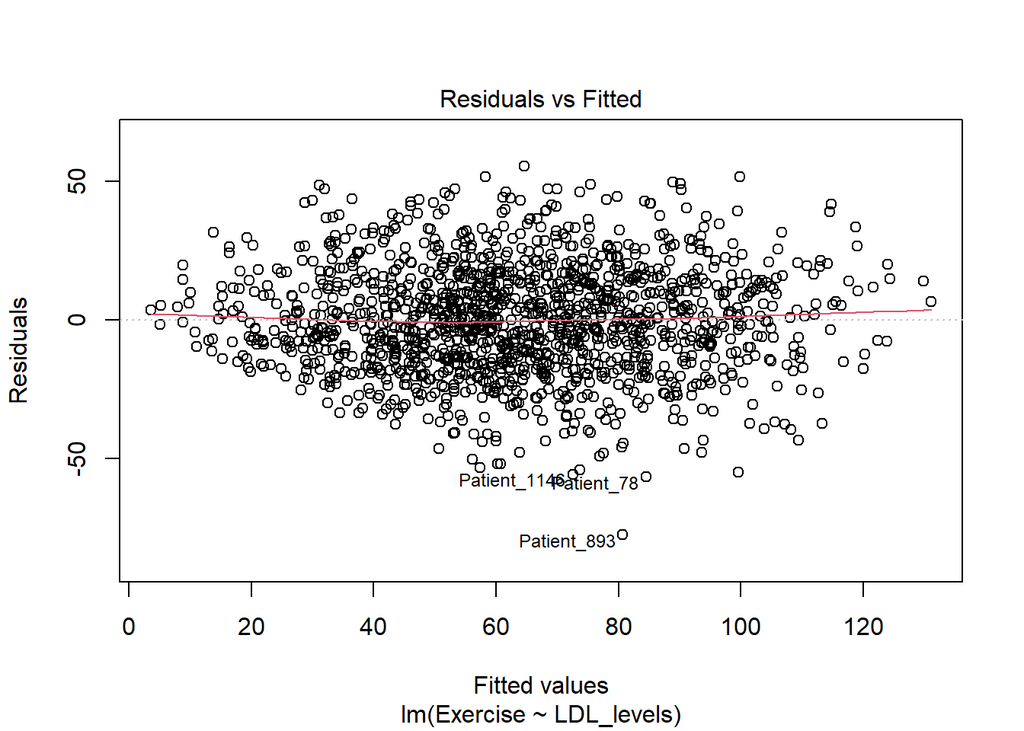

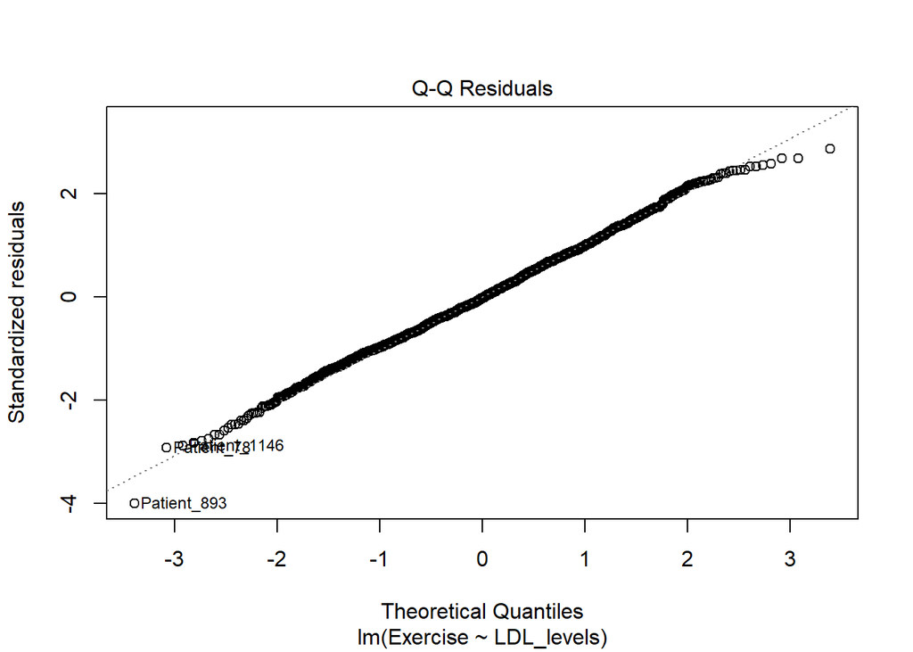

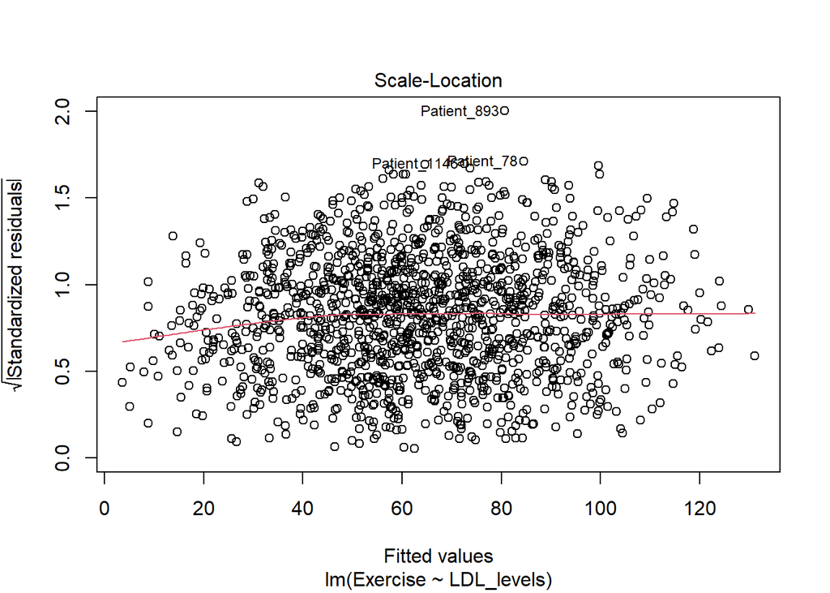

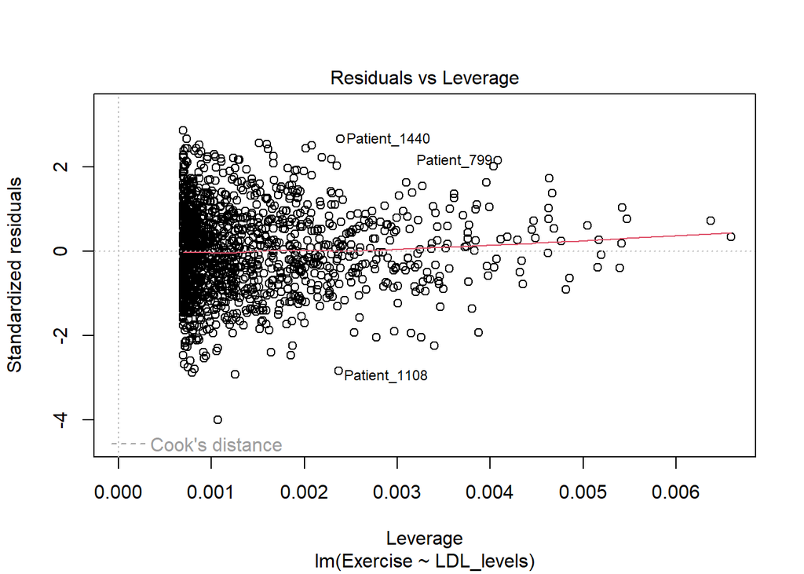

```r
plot(linear_model)
```

### 4. Checking residual errors

To validate our model, in addition to checking the p-values of the intercept $\beta_0$ and slope $\beta_1$ (both <2e-16 ), we must verify that the residuals follow a normal distribution. We can easily check this using the Shapiro-Wilk test on the model’s residuals.

```r
test_n <- shapiro.test(residuals(linear_model))
print(test_n)
```

```
##
##  Shapiro-Wilk normality test
##
## data:  residuals(linear_model)
## W = 0.9983, p-value = 0.1571
```